DS 6030 | Fall 2024 | University of Virginia

# Homework #2: Resampling

Author

Kiana Dane

Published

September 29, 2024

# Required R packages and Directories

```r
data_dir = 'https://mdporter.github.io/teaching/data/' # data directory
library(tidymodels)# for optional tidymodels solutions
library(tidyverse) # functions for data manipulation
library(ggplot2)
```

# Problem 1: Bootstrapping

Bootstrap resampling can be used to quantify the uncertainty in a fitted curve.

## a. Data Generating Process

Create a set of functions to generate data from the following distributions:
$$\begin{align*}
X &\sim \mathcal{U}(0, 2) \qquad \text{Uniform between $0$ and $2$}\\
Y &= 1 + 2x + 5\sin(5x) + \epsilon \\
\epsilon &\sim \mathcal{N}(0,\, \sigma=2.5)
\end{align*}$$

**Solution**

```r
create_x <- function(n) runif(n, min = 0, max = 2)

func_true <- function(x) 1 + 2 * x + 5 * sin(5 * x)

create_y <- function(x) {
  n = length(x)
  func_true(x) + rnorm(n, sd=2.5)
}
```

## b. Simulate data

Simulate $n=100$ realizations from these distributions. Produce a scatterplot and draw the true regression line $f(x) = E[Y \mid X=x]$. Use `set.seed(211)` prior to generating the data.

**Solution**

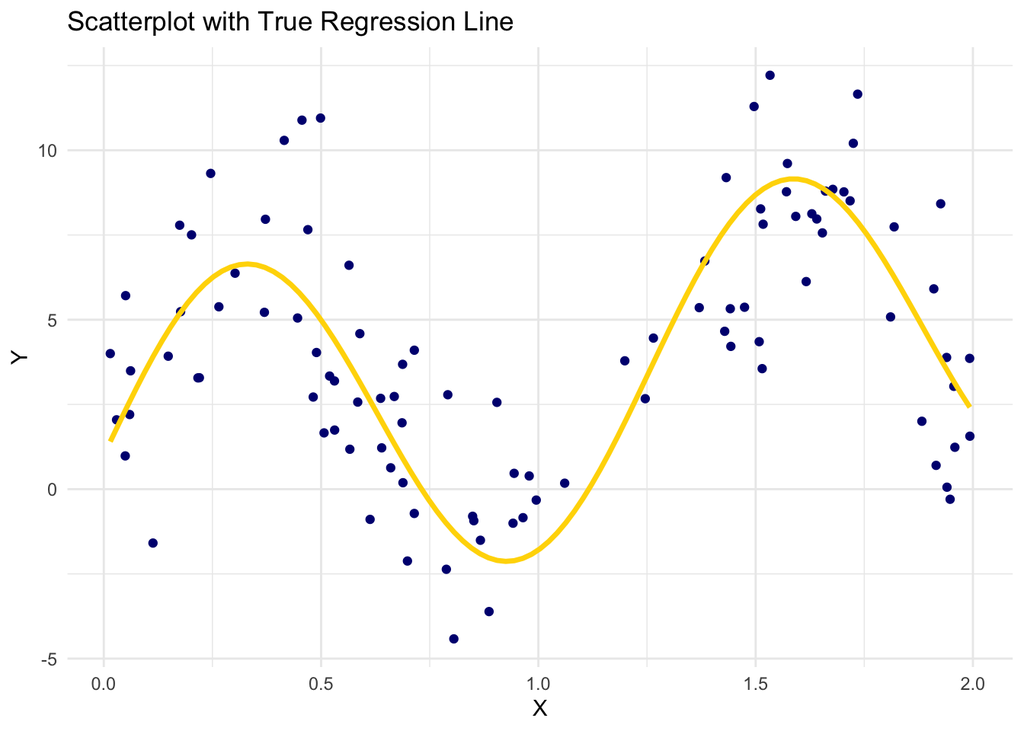

```r
set.seed(211)

n <- 100
x = create_x(n)
y = create_y(x)
prob1b_data <- data.frame(x,y)

ggplot(prob1b_data, aes(x = x, y = y)) +
  geom_point(color = "navy") +
  stat_function(fun = func_true, color = "gold", size = 1.2) +
  labs(title = "Scatterplot with True Regression Line",
       x = "X",
       y = "Y") +
  theme_minimal()
```

## c. 5th degree polynomial fit

Fit a 5th degree polynomial. Produce a scatterplot and draw the *estimated* regression curve.

**Solution**

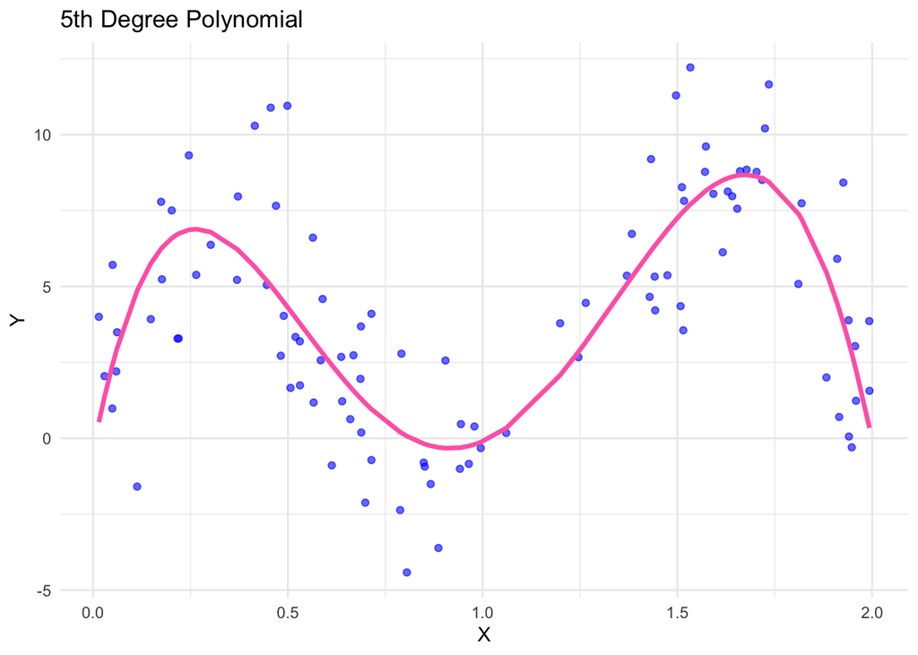

```r
poly_model <- lm(y ~ poly(x, 5), data = prob1b_data)

prob1b_data$predicted_Y <- predict(poly_model, newdata = prob1b_data)

ggplot(prob1b_data, aes(x = x, y = y)) +
  geom_point(color = "blue", alpha = 0.6) +
  geom_line(aes(y = predicted_Y), color = "hotpink", size = 1.2) +
  labs(title = "5th Degree Polynomial",
       x = "X",
       y = "Y") +
  theme_minimal()
```

## d. Bootstrap sampling

Make 200 bootstrap samples. For each bootstrap sample, fit a 5th degree polynomial and make predictions at `eval_pts = seq(0, 2, length=100)`

- Set the seed (use `set.seed(212)`) so your results are reproducible.
- Produce a scatterplot with the original data and add the 200 bootstrap curves

**Solution**

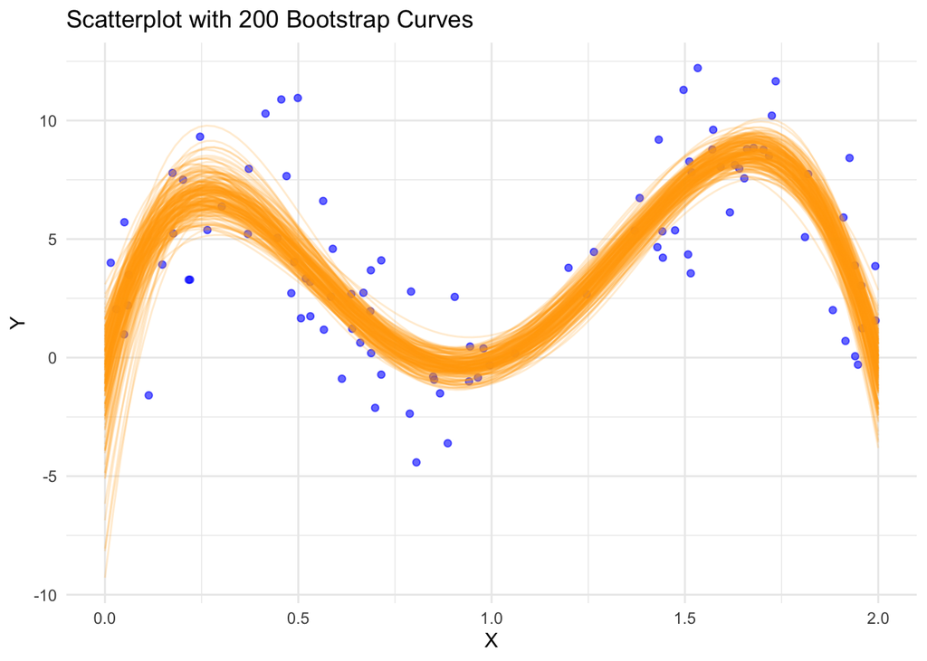

```r
library(boot)
library(ggplot2)

set.seed(212)

# Number of bootstrap samples
m <- 200

eval_pts <- seq(0, 2, length = 100)

bootstrap_preds <- matrix(0, nrow = 100, ncol = m)

n <- nrow(prob1b_data)

# 200 bootstrap samples
for (i in 1:m) {

  bootstrap_sample <- prob1b_data[sample(1:n, size = n, replace = TRUE), ]

  poly_model_boot <- lm(y ~ poly(x, 5), data = bootstrap_sample)

  bootstrap_preds[, i] <- predict(poly_model_boot, newdata = data.frame(x = eval_pts))
}

bootstrap_df <- data.frame(eval_pts = eval_pts, bootstrap_preds)


bootstrap_long <- bootstrap_df %>%
  pivot_longer(cols = -eval_pts, names_to = "bootstrap_sample", values_to = "y_pred")

plot_data <- ggplot(prob1b_data, aes(x = x, y = y)) +
  geom_point(color = "blue", alpha = 0.6) +
  labs(title = "Scatterplot with 200 Bootstrap Curves",
       x = "X",
       y = "Y") +
  theme_minimal()

plot_data <- plot_data +
  geom_line(data = bootstrap_long, aes(x = eval_pts, y = y_pred, group = bootstrap_sample),
            color = "orange", alpha = 0.2, size = 0.5)

print(plot_data)
```

## e. Confidence Intervals

Calculate the pointwise 95% confidence intervals from the bootstrap samples. That is, for each $x \in {\rm eval\_pts}$, calculate the upper and lower limits such that only 5% of the curves fall outside the interval at $x$.

- Remake the plot from part *c*, but add the upper and lower boundaries from the 95% confidence intervals.

**Solution**

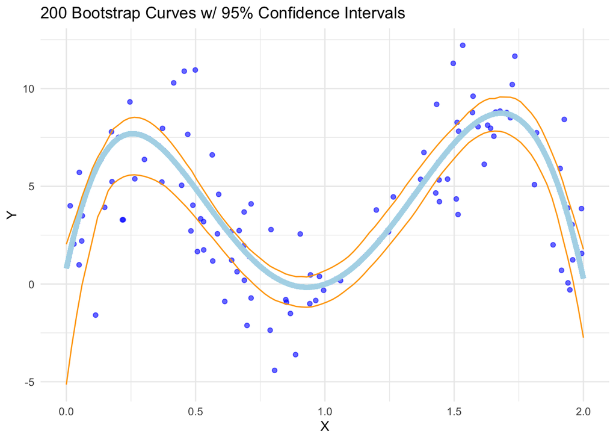

```r
set.seed(212)

eval_pts <- seq(0, 2, length = 100)

bootstrap_preds <- matrix(0, nrow = 100, ncol = 200)

n <- nrow(prob1b_data)
for (i in 1:200) {
  bootstrap_sample <- prob1b_data[sample(1:n, size = n, replace = TRUE), ]

  poly_model_boot <- lm(y ~ poly(x, 5), data = bootstrap_sample)

  bootstrap_preds[, i] <- predict(poly_model_boot, newdata = data.frame(x = eval_pts))
}

lower_bound <- apply(bootstrap_preds, 1, quantile, probs = 0.025)
upper_bound <- apply(bootstrap_preds, 1, quantile, probs = 0.975)

plot_data <- ggplot(prob1b_data, aes(x = x, y = y)) +
  geom_point(color = "blue", alpha = 0.6) +
  labs(title = "200 Bootstrap Curves w/ 95% Confidence Intervals",
       x = "X",
       y = "Y") +
  theme_minimal()

for (i in 1:200) {
  plot_data <- plot_data +
    geom_line(aes(x = eval_pts, y = bootstrap_preds[, i]), color = "lightblue", alpha = 0.2, size = 2)
}

plot_data <- plot_data +
  geom_line(aes(x = eval_pts, y = lower_bound), color = "orange") +
  geom_line(aes(x = eval_pts, y = upper_bound), color = "orange")

print(plot_data)
```

# Problem 2: V-Fold cross-validation with $k$ nearest neighbors

Run 10-fold cross-validation on the data generated in part 1b to select the optimal $k$ in a k-nearest neighbor (kNN) model. Then evaluate how well cross-validation performed by evaluating the performance on a large test set. The steps below will guide you.

## a. Implement 10-fold cross-validation

Use $10$-fold cross-validation to find the value of $k$ (i.e., neighborhood size) that provides the smallest cross-validated MSE using a kNN model.

- Search over $k=3,4,\ldots, 40$.
- Use `set.seed(221)` prior to generating the folds to ensure the results are replicable.
- Show the following:
  - the optimal $k$ (as determined by cross-validation)
  - the corresponding estimated MSE
  - produce a plot with $k$ on the x-axis and the estimated MSE on the y-axis (optional: add 1-standard error bars).

**Solution**

```r
library(class)
library(caret)
library(FNN)
library(ggplot2)

set.seed(211)

n <- 100
x = create_x(n)
y = create_y(x)
prob2a_data <- tibble(x,y)
```

```r
K = 3:40

knn_func <- function(fit, evaluate, K) {
  MSE = numeric(length(K))
  for(i in 1:length(K)) {
    k = K[i]
    knn = FNN::knn.reg(train = fit %>% select(x),
                       y = fit$y,
                       test = evaluate %>% select(x),
                       k = k)
    r.val = evaluate$y - knn$pred
    MSE[i] = mean(r.val^2)
  }
tibble(k = K, mse = MSE, n_eval = nrow(evaluate))
}
```

```r
set.seed(221)
n.folds = 10
fold = sample(rep(1:n.folds, length = nrow(prob2a_data)))

out = vector("list", n.folds)
for(h in 1:n.folds){

  val = which(fold == h)
  train = which(fold != h)

  out[[h]] = knn_func(
    fit = prob2a_data[train,],
    evaluate = prob2a_data[val,], K = 3:40) %>%
    mutate(fold = h)
}
out = bind_rows(out)

out
```

```
# A tibble: 380 × 4
      k   mse n_eval  fold
  <int> <dbl>  <int> <int>
1     3 10.5      10     1
2     4  7.05     10     1
3     5  7.33     10     1
4     6  6.54     10     1
5     7  6.70     10     1
6     8  6.58     10     1
# ℹ 374 more rows
```

```r
performance =
  out %>%
  group_by(k) %>%
    summarize(
      n_folds = n(),
      MSE = mean(mse),
      MSE2 = sum(n_eval*mse) / sum(n_eval),
      SE = sd(mse)/sqrt(n)
    ) %>%
  arrange(MSE)

performance
```

```
# A tibble: 38 × 5
      k n_folds   MSE  MSE2    SE
  <int>   <int> <dbl> <dbl> <dbl>
1     8      10  5.94  5.94 0.189
2     9      10  6.03  6.03 0.179
3    11      10  6.09  6.09 0.196
4     6      10  6.14  6.14 0.200
5     7      10  6.18  6.18 0.187
6    10      10  6.21  6.21 0.188
# ℹ 32 more rows
```

```r
performance %>% slice_min(MSE)
```

```
# A tibble: 1 × 5
      k n_folds   MSE  MSE2    SE
  <int>   <int> <dbl> <dbl> <dbl>
1     8      10  5.94  5.94 0.189
```

```r
performance
```

```
# A tibble: 38 × 5
      k n_folds   MSE  MSE2    SE
  <int>   <int> <dbl> <dbl> <dbl>
1     8      10  5.94  5.94 0.189
2     9      10  6.03  6.03 0.179
3    11      10  6.09  6.09 0.196
4     6      10  6.14  6.14 0.200
5     7      10  6.18  6.18 0.187
6    10      10  6.21  6.21 0.188
# ℹ 32 more rows
```

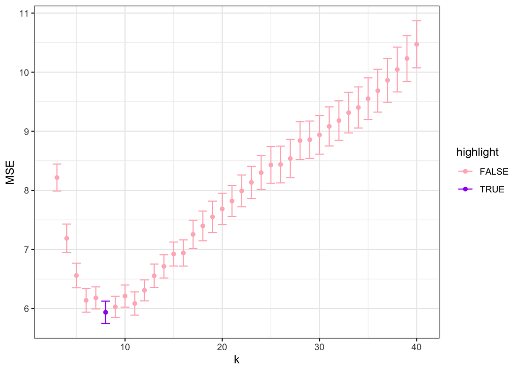

```r
performance %>%
  mutate(highlight = ifelse(MSE == min(MSE), TRUE, FALSE)) %>%
  ggplot(aes(k, color=highlight)) +
  geom_point(aes(y=MSE)) +
  geom_errorbar(aes(ymin=MSE - SE, ymax=MSE+SE)) +
  scale_color_manual(values=c("lightpink", "purple"))
```

## b. Find the optimal *edf*

The $k$ (number of neighbors) in a kNN model determines the effective degrees of freedom *edf*. What is the optimal *edf*? Be sure to use the correct sample size when making this calculation. Produce a plot similar to that from part *a*, but use *edf* (effective degrees of freedom) on the x-axis.

**Solution**

```r
performance = performance %>% mutate(edf = (nrow(prob2a_data)*9/10)/k)
performance %>% slice_min(MSE)
```

```
# A tibble: 1 × 6
      k n_folds   MSE  MSE2    SE   edf
  <int>   <int> <dbl> <dbl> <dbl> <dbl>
1     8      10  5.94  5.94 0.189  11.2
```

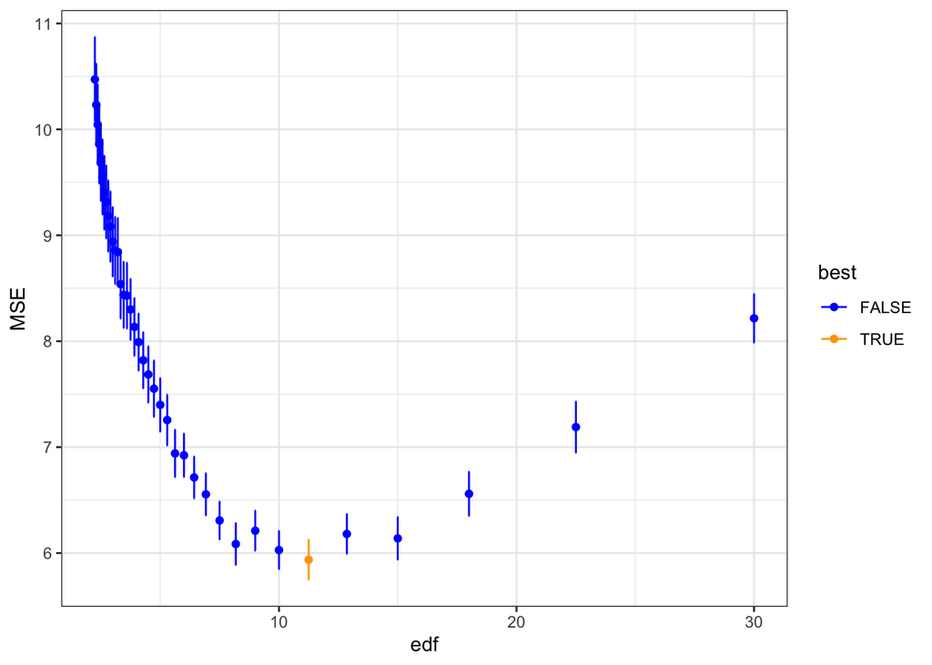

```r
performance %>%
  mutate(best = ifelse(MSE == min(MSE), TRUE, FALSE)) %>%
  ggplot(aes(edf, color=best))+
  geom_point(aes(y=MSE)) +
  geom_errorbar(aes(ymin=MSE - SE, ymax=MSE + SE)) +
  scale_color_manual(values=c("blue", "orange"))
```

## c. Choose $k$

After running cross-validation, a final model fit from *all* of the training data needs to be produced to make predictions. What value of $k$ would you choose? Why?

**Solution**

I would choose k=11 - this is because though it is evident that k=8 produces the lowest MSE, k=9 and k=11 have similar MSEs and allow for slightly more conservative choice with reduced variance.

## d. Evaluate actual performance

Now we will see how well cross-validation performed. Simulate a test data set of $50000$ observations from the same distributions. Use `set.seed(223)` prior to generating the test data.

- Fit a set of kNN models, using the full training data, and calculate the mean squared error (MSE) on the test data for each model. Use the same $k$ values in *a*.
- Report the optimal $k$, the corresponding *edf*, and MSE based on the test set.

**Solution**

```r
test_n = 50000
set.seed(223)
test_xvals = create_x(test_n)
test_yvals = create_y(test_xvals)

test_2d = tibble(x = test_xvals, y = test_yvals)

results_test = knn_func(prob1b_data, test_2d, K = 3:40) %>%
  mutate(edf = nrow(prob1b_data)/k)

results_test %>% slice_min(mse)
```

```
# A tibble: 1 × 4
      k   mse n_eval   edf
  <int> <dbl>  <int> <dbl>
1    13  7.11  50000  7.69
```

## e. Performance plots

Plot both the cross-validation estimated and (true) error calculated from the test data on the same plot. See Figure 5.6 in ISL (pg 182) as a guide.

- Produce two plots: one with $k$ on the x-axis and one with *edf* on the x-axis.
- Each plot should have two lines: one from part *a* and one from part *d*

**Solution**

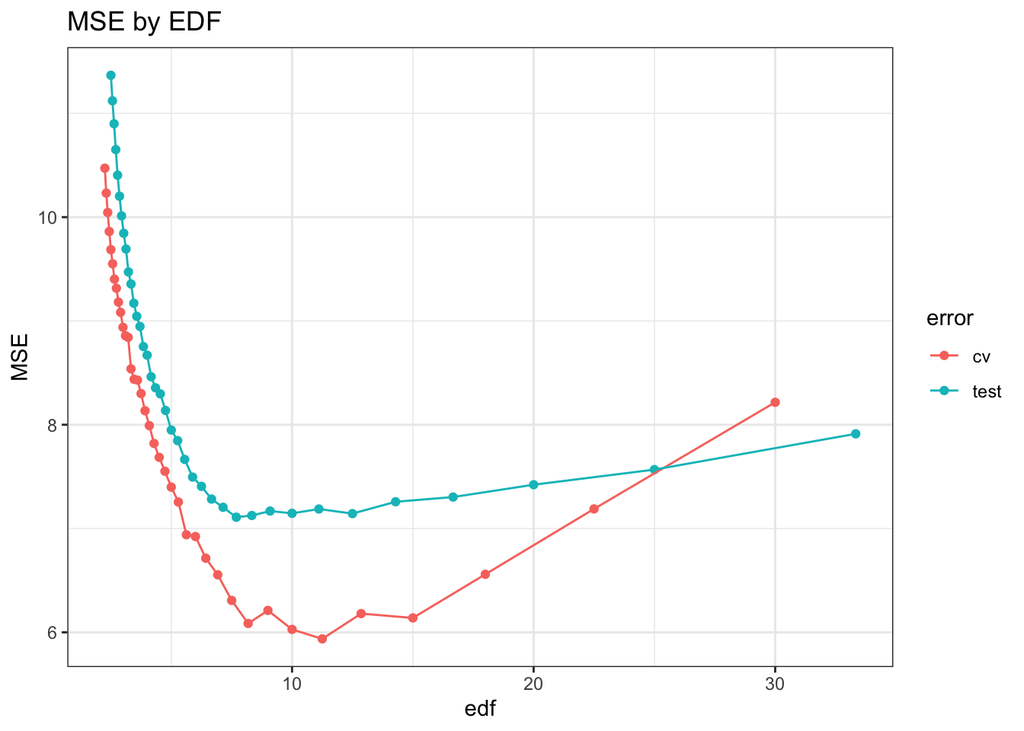

```r
bind_rows(
  cv = performance,
  test = results_test %>% rename(MSE = mse),
  .id="error"
  ) %>%
  ggplot(aes(edf, MSE, color=error)) +
  geom_point() + geom_line() +
  labs(title="MSE by EDF")
```

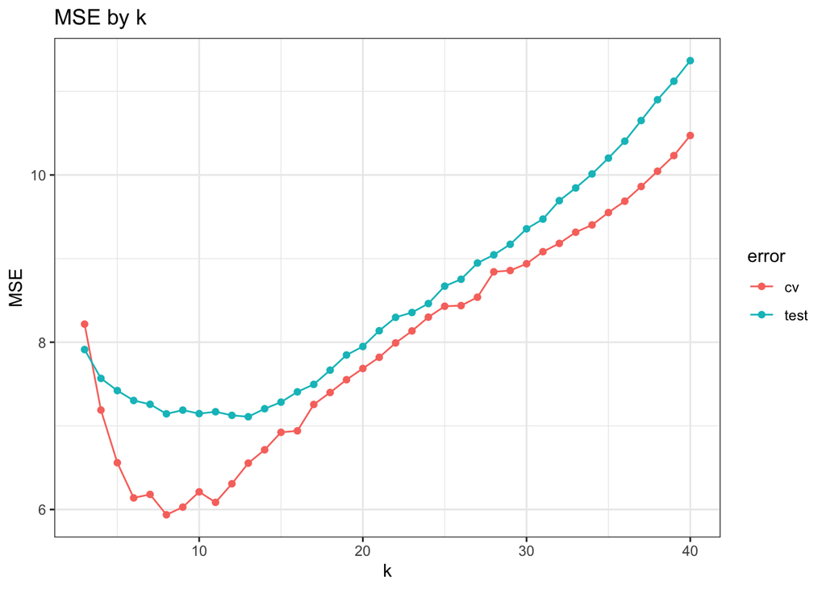

```r
bind_rows(
  cv = performance,
  test = results_test %>% rename(MSE = mse),
  .id="error"
  ) %>%
  ggplot(aes(k, MSE, color=error)) +
  geom_point() + geom_line() +
  labs(title="MSE by k")
```

## f. Did cross-validation work as intended?

Based on the plots from *e*, does it appear that cross-validation worked as intended? How sensitive is the choice of $k$ on the resulting test MSE?

**Solution**

Based on these two plots, it appears that cross-validation did work as intended by selecting values for k that produce results with low MSEs. The best solution was not recommended.